# Tarea10

Abraham Nieto 51556

5 de noviembre de 2017

```r
knitr::opts_chunk$set(
    comment = "#>",
    collapse = TRUE,
    fig.width=3, fig.height=3
)
comma <- function(x) format(x, digits = 2, big.mark = ",")
options(digits=3)

library(tidyverse)
library(gridExtra)
theme_set(theme_minimal())
```

12-Estadística bayesiana 1. Modelo Beta-Binomial Una compañía farmacéutica afirma que su nueva medicina incrementa la probabilidad de concebir un niño (sexo masculino), pero aún no publican estudios. Supón que conduces un experimento en el cual 50 parejas se seleccionan de manera aleatoria de la población, toman la medicina y conciben un bebé, nacen 30 niños y 20 niñas.

Quieres estimar la probabilidad de concebir un niño para parejas que toman la medicina. ¿Cuál es una inicial apropiada? No tiene que estar centrada en 0.5 pues esta corresponde a personas que no toman la medicina, y la inicial debe reflejar tu incertidumbre sobre el efecto de la droga.

```r
30/50
```

```
#> [1] 0.6
```

Usando tu inicial de a) grafica la posterior y decide si es creíble que las parejas que toman la medicina tienen una probabilidad de 0.5 de concebir un niño.

```r
theta <- seq(0.05,0.95, 0.1)
pesos.prior <- c(1, 5.2, 8, 7.2, 4.6, 2.1, 0.7, 0.1, 0, 0)
prior <- pesos.prior/sum(pesos.prior)
prior_df <- data_frame(theta, prior = round(prior, 3))
prior_df
```

```
#> # A tibble: 10 x 2
#>    theta prior
#>    <dbl> <dbl>
#>  1  0.05 0.035
#>  2  0.15 0.180
#>  3  0.25 0.277
#>  4  0.35 0.249
#>  5  0.45 0.159
#>  6  0.55 0.073
#>  7  0.65 0.024
#>  8  0.75 0.003
#>  9  0.85 0.000
#> 10  0.95 0.000
```

```r
library(LearnBayes)
N <- 50 # parejas
z <- 30 # éxitos

# Verosimilitud
Like <- theta ^ z * (1 - theta) ^ (N - z)
product <- Like * prior

# Distribución posterior (normalizamos)
post <- product / sum(product)

dists <- bind_cols(prior_df, post = post)
round(dists, 3)
```

```
#> # A tibble: 10 x 3
#>    theta prior  post
#>    <dbl> <dbl> <dbl>
#>  1  0.05 0.035 0.000
#>  2  0.15 0.180 0.000
#>  3  0.25 0.277 0.000
#>  4  0.35 0.249 0.004
#>  5  0.45 0.159 0.180
#>  6  0.55 0.073 0.612
#>  7  0.65 0.024 0.201
#>  8  0.75 0.003 0.003
#>  9  0.85 0.000 0.000
#> 10  0.95 0.000 0.000
```

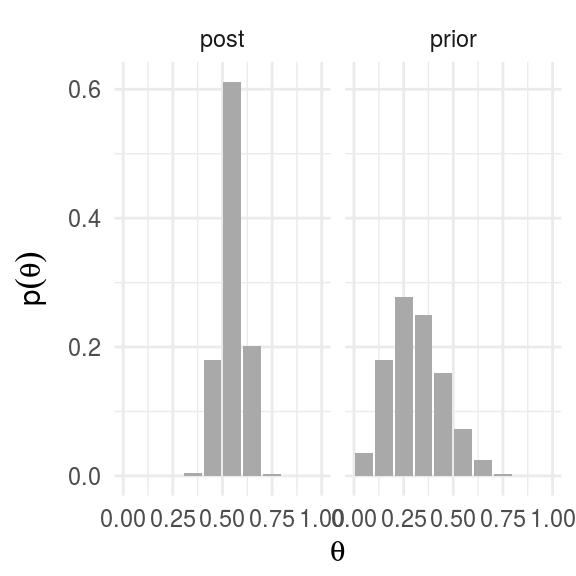

```r
dists_l <- dists %>%
  gather(dist, val, prior:post)

ggplot(dists_l, aes(x = theta, y = val)) +
  geom_bar(stat = "identity", fill = "darkgray") +
  facet_wrap(~ dist) +
  labs(x = expression(theta), y = expression(p(theta)))
```

De hecho viendo la aposteriori podemos decir que hasta más de 0.5.

Supón que la farmacéutica asevera que la probabilidad de concebir un niño cuando se toma la medicina es cercana al 60% con alta certeza. Representa esta postura con una distribución inicial Beta(60,40). Comparala con la inicial de un escéptico que afirma que la medicina no hace diferencia, representa esta creencia con una inicial Beta(50,50). Recuerda que p(x)=Beta(z+a,N−z+b)/Beta(a,b) p(x)=Beta(z+a,N−z+b)/Beta(a,b) Calcula el valor de p(x)p(x) para cada modelo y el factor de Bayes (asume p(M1)=p(M2)=0.5p(M1)=p(M2)=0.5).

```r
N = 50; z = 30; a = 60; b = 40
#con Beta(60,40)
p1<-beta(z+a,N-z+b)/beta(a,b)
#modelo 60,40
p1
```

```
#> [1] 1.98e-15
```

```r
N = 50; z = 30; a = 50; b =50
#con Beta(50,50)
p2<-beta(z+a,N-z+b)/beta(a,b)
#modelo 50,50
p2
```

```
#> [1] 1.01e-15
```

```r
#Factor de Bayes:
p1/p2
```

```
#> [1] 1.96
```

2. Otra familia conjugada Supongamos que nos interesa analizar el IQ de una muestra de estudiantes del ITAM y suponemos que el IQ de un estudiante tiene una distribución normal x∼N(θ,σ2)x∼N(θ,σ2) con σ2σ2 conocida.

Realizaremos un análisis bayesiano por lo que hace falta establer una distribución inicial, elegimos p(θ)p(θ) que se distribuya N(μ,τ2)N(μ,τ2) donde elegimos los parámetros μ,τμ,τ que mejor describan nuestras creencias iniciales, por ejemplo si tengo mucha certeza de que el IQIQ promedio se ubica en 150, elegiría μ=150μ=150 y una desviación estándar chica por ejemplo τ=5τ=5. Entonces la distribución inicial es:

Calcula la distribución posterior p(θ|x)∝p(x|θ)p(θ)p(θ|x)∝p(x|θ)p(θ), usando la inicial y verosimilitud que definimos arriba. Una vez que realices la multiplicación debes identificar el núcleo de una distribución Normal, ¿cuáles son sus parámetros (media y varianza)?

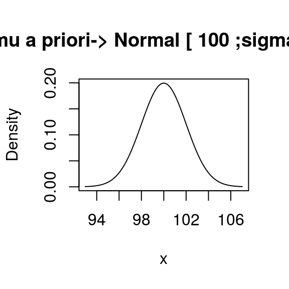

```r
#varianza de la población conocida
sigma2=8
tau=1/8
#a priori
media0=100
varianza0=4
sd0=sqrt(varianza0)
tau0=1/4
.x <- seq(media0-3.5126*sd0, media0+3.5126*sd0, length.out=1000)
plot(.x, dnorm(.x, mean=media0, sd=2), type="l", xlab="x",
 ylab="Density",
 main=paste("mu a priori-> Normal [",media0,";sigma=",sd0, "]"))
```

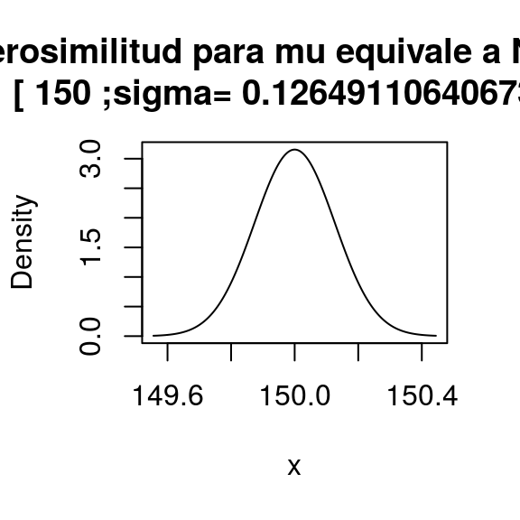

```r
remove(.x)
#muestra
n=20
mediamuestral=150
varianzamuestral=25
# equivalencia de la verosimilitud
varequival=sigma2/(n*varianzamuestral)
sdequival=sqrt(varequival)
.x <- seq(mediamuestral-3.5126*sdequival, mediamuestral+3.5126*sdequival,
length.out=1000)
plot(.x, dnorm(.x, mean=mediamuestral, sd=sdequival), type="l", xlab="x",
 ylab="Density",
 main=paste(" verosimilitud para mu equivale a Normal
[",mediamuestral,";sigma=",sdequival, "]"))
```

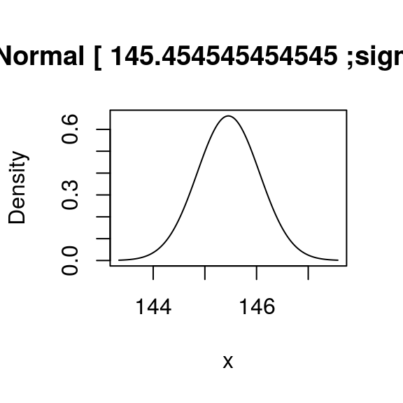

```r
remove(.x)
## a posteriori
media1=(tau0*media0+n*tau*mediamuestral)/(tau0+n*tau)
tau1=tau0+n*tau
sd1=sqrt(1/tau1)
.x <- seq(media1-3.5126*sd1, media1+3.5126*sd1, length.out=1000)
plot(.x, dnorm(.x, mean=media1, sd=sd1), type="l", xlab="x",
 ylab="Density",
 main=paste(" mu a posterriori -> Normal [",media1,";sigma=",sd1, "]"))
```

```r
remove(.x)
```

3. Metropolis En el ejercicio anterior hiciste cálculos para el caso de una sola observación. En este ejercicio consideramos el caso en que observamos una muestra x={x1,…,xN}x={x1,…,xN}.

Crea una función priorprior que reciba los parámetros μμ y ττ que definen tus creencias del parámetro desconocido θθ y devuelva p(θ)p(θ), donde p(θ)p(θ) tiene distriución N(μ,σ2)

```r
prior <- function(mu, tau){
  function(theta){
    dnorm(theta, mean=mu, sd=tau)
  }
}
```

b.Utiliza la función que acabas de escribir para definir una distribución inicial con parámetros μ=150μ=150 y τ=15τ=15, llámala mi_prior. Ya que tenemos la distribución inicial debemos escribir la verosimilitud, en este caso la verosimilitud es:

```r
mi_prior<-prior(150,15)
```

c.Crea una función likeNormlikeNorm en R que reciba la desviación estándar, la suma de los valores observados ∑xi∑xi, la suma de los valores al cuadrado ∑x2i∑xi2 y el número de observaciones NN la función devolverá la función de verosimilitud (es decir va a regresar una función que depende únicamente de θθ).

```r
# S: sum x_i, S2: sum x_i^2, N: número obs.
likeNorm <- function(S, S2, N){
  function(theta){

    (1/((2*pi*20**2)**(N/2)))*exp((-1/(2*20**2))*(S2-2*theta*S+N*theta**2))

  }
}
```

```r
mi_like<-likeNorm(13000,1700000,100)
```

e.La distribución posterior no normalizada es simplemente el producto de la inicial y la posterior:

```r
postRelProb <- function(theta){
  mi_like(theta) * mi_prior(theta)
}
```

Utiliza Metropolis para obtener una muestra de valores representativos de la distribución posterior de θθ. Para proponer los saltos utiliza una Normal(0, 5).

Grafica los valores de la cadena para cada paso.

```r
library(ggplot2)
# para cada paso decidimos el movimiento de acuerdo a la siguiente función
caminaAleat <- function(theta){ # theta: valor actual
  salto_prop <- rnorm(1, 0, sd = 5) # salto propuesto
  theta_prop <- theta + salto_prop # theta propuesta
  if(theta_prop < 0 | theta_prop > 1){ # si el salto implica salir del dominio
    return(theta)
  }
  u <- runif(1)
  p_move <-  min(ifelse(postRelProb(theta)!=0,postRelProb(theta_prop) / postRelProb(theta),1.1), 1) # prob mover
  print(p_move)
  if(p_move  > u){
    return(theta_prop) # aceptar valor propuesto
  }
  else{
    return(theta) # rechazar
  }
}

set.seed(47405)

pasos <- 6000
camino <- numeric(pasos) # vector que guardará las simulaciones
camino[1] <- 0.1 # valor inicial

# Generamos la caminata aleatoria
for (j in 2:pasos){
  camino[j] <- caminaAleat(camino[j - 1])
}
```

[output not shown]

[output cut: 437 more lines]

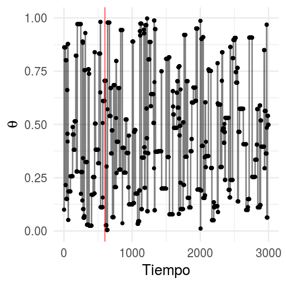

```r
caminata <- data.frame(pasos = 1:pasos, theta = camino)

ggplot(caminata[1:3000, ], aes(x = pasos, y = theta)) +
  geom_point(size = 0.8) +
  geom_path(alpha = 0.5) +
  scale_y_continuous(expression(theta), limits = c(0, 1)) +
  scale_x_continuous("Tiempo") +
  geom_vline(xintercept = 600, color = "red", alpha = 0.5)
```